# Final analysis code

## 5.2 Hyp 2: barriers tx causes respondents to rate it more important to prioritize that group

RJ note: programming issue so cant use (or can only use for female condition) since issue w/ parallel q structure across W and M

```r
## notes on importance ratings
#  The  first  asks  respondents  whether  it  is  important  for  a  method  toprioritize [women/minority-owned] businesses (Yes;  No;  Not sure).  The secondquestion depends on responses to the first question:  respondents who indicatedthat it wasnotimportant to prioritize [women/minority-owned] businesses will beasked how important it is that the underserved group was not advantaged, whilerespondents who indicated that itwasimportant to prioritize those businesses willbe asked how important it is that the underserved group got an advantage.  Wewill combine these two questions to create a scale ranging from -3 (very important5
# that underserved group got no advantage) to 0 (not sure) to 3 (very importantthat underserved group got an advantage)
```

## 5.3 Hyp 3: differences in tx effect between minority barriers treatment and women’s barrier treatment

1. Filter to respondents randomized to those two
2. Reg is comparing those two

```r
## filter to some barrier randomization
barriers_r = model_df %>%
        filter(cond != "No_info")


## when women is the tx, slightly more likely
## to rank points higher/first than when minority is tx
m1 <- lm(points_rank ~ cond,
           data = barriers_r)

m2 <- lm(is_points_first ~ cond,
           data = barriers_r)

summary(m1)
```

```
##
## Call:
## lm(formula = points_rank ~ cond, data = barriers_r)
##
## Residuals:
##     Min      1Q  Median      3Q     Max
## -0.6018 -0.6018 -0.5833  0.4167  1.4167
##
## Coefficients:
##             Estimate Std. Error t value Pr(>|t|)
## (Intercept)  1.60177    0.04230  37.869   <2e-16 ***
## condWom     -0.01844    0.05894  -0.313    0.755
## ---
## Signif. codes:  0 '***' 0.001 '**' 0.01 '*' 0.05 '.' 0.1 ' ' 1
##
## Residual standard error: 0.7788 on 697 degrees of freedom
## Multiple R-squared:  0.0001404,  Adjusted R-squared:  -0.001294
## F-statistic: 0.09785 on 1 and 697 DF,  p-value: 0.7545
```

```r
summary(m2)
```

```
##
## Call:
## lm(formula = is_points_first ~ cond, data = barriers_r)
##
## Residuals:
##     Min      1Q  Median      3Q     Max
## -0.5944 -0.5841  0.4056  0.4159  0.4159
##
## Coefficients:
##             Estimate Std. Error t value Pr(>|t|)
## (Intercept)  0.58407    0.02676  21.830   <2e-16 ***
## condWom      0.01037    0.03728   0.278    0.781
## ---
## Signif. codes:  0 '***' 0.001 '**' 0.01 '*' 0.05 '.' 0.1 ' ' 1
##
## Residual standard error: 0.4926 on 697 degrees of freedom
## Multiple R-squared:  0.0001111,  Adjusted R-squared:  -0.001323
## F-statistic: 0.07742 on 1 and 697 DF,  p-value: 0.7809
```

```r
## save
stargazer(m1,
          m2,
          type = "html",
          out=here("output/tables/womenvmob_barriers_regs.doc"))
```

```
##
## <table style="text-align:center"><tr><td colspan="3" style="border-bottom: 1px solid black"></td></tr><tr><td style="text-align:left"></td><td colspan="2"><em>Dependent variable:</em></td></tr>
## <tr><td></td><td colspan="2" style="border-bottom: 1px solid black"></td></tr>
## <tr><td style="text-align:left"></td><td>points_rank</td><td>is_points_first</td></tr>
## <tr><td style="text-align:left"></td><td>(1)</td><td>(2)</td></tr>
## <tr><td colspan="3" style="border-bottom: 1px solid black"></td></tr><tr><td style="text-align:left">condWom</td><td>-0.018</td><td>0.010</td></tr>
## <tr><td style="text-align:left"></td><td>(0.059)</td><td>(0.037)</td></tr>
## <tr><td style="text-align:left"></td><td></td><td></td></tr>
## <tr><td style="text-align:left">Constant</td><td>1.602<sup>***</sup></td><td>0.584<sup>***</sup></td></tr>
## <tr><td style="text-align:left"></td><td>(0.042)</td><td>(0.027)</td></tr>
## <tr><td style="text-align:left"></td><td></td><td></td></tr>
## <tr><td colspan="3" style="border-bottom: 1px solid black"></td></tr><tr><td style="text-align:left">Observations</td><td>699</td><td>699</td></tr>
## <tr><td style="text-align:left">R<sup>2</sup></td><td>0.0001</td><td>0.0001</td></tr>
## <tr><td style="text-align:left">Adjusted R<sup>2</sup></td><td>-0.001</td><td>-0.001</td></tr>
## <tr><td style="text-align:left">Residual Std. Error (df = 697)</td><td>0.779</td><td>0.493</td></tr>
## <tr><td style="text-align:left">F Statistic (df = 1; 697)</td><td>0.098</td><td>0.077</td></tr>
## <tr><td colspan="3" style="border-bottom: 1px solid black"></td></tr><tr><td style="text-align:left"><em>Note:</em></td><td colspan="2" style="text-align:right"><sup>*</sup>p<0.1; <sup>**</sup>p<0.05; <sup>***</sup>p<0.01</td></tr>
## </table>
```

## 5.4 Hyp 4: interaction between treatment and respondent’s status in underserved group

Similar to above, filters to those randomized to one of the barrier conditions

```r
## women
summary(lm(points_rank ~ cond*is_woman,
           data = barriers_r))
```

```
##
## Call:
## lm(formula = points_rank ~ cond * is_woman, data = barriers_r)
##
## Residuals:
##     Min      1Q  Median      3Q     Max
## -0.6205 -0.6169 -0.5409  0.4162  1.4591
##
## Coefficients:
##                      Estimate Std. Error t value Pr(>|t|)
## (Intercept)           1.62048    0.06049  26.790   <2e-16 ***
## condWom              -0.07960    0.08648  -0.920    0.358
## is_womanTRUE         -0.03667    0.08467  -0.433    0.665
## condWom:is_womanTRUE  0.11270    0.11837   0.952    0.341
## ---
## Signif. codes:  0 '***' 0.001 '**' 0.01 '*' 0.05 '.' 0.1 ' ' 1
##
## Residual standard error: 0.7793 on 695 degrees of freedom
## Multiple R-squared:  0.001624,   Adjusted R-squared:  -0.002686
## F-statistic: 0.3768 on 3 and 695 DF,  p-value: 0.7698
```

```r
## minority
summary(lm(points_rank ~ relevel(factor(cond),
                                    ref = "Wom")*is_minority,
           data = barriers_r))
```

```
##
## Call:
## lm(formula = points_rank ~ relevel(factor(cond), ref = "Wom") *
##     is_minority, data = barriers_r)
##
## Residuals:
##     Min      1Q  Median      3Q     Max
## -0.6364 -0.6015 -0.5353  0.3985  1.4845
##
## Coefficients:
##                                                       Estimate Std. Error
## (Intercept)                                            1.60153    0.04820
## relevel(factor(cond), ref = "Wom")Min                  0.03483    0.06949
## is_minorityTRUE                                       -0.06618    0.09191
## relevel(factor(cond), ref = "Wom")Min:is_minorityTRUE -0.05472    0.13117
##                                                       t value Pr(>|t|)
## (Intercept)                                            33.227   <2e-16 ***
## relevel(factor(cond), ref = "Wom")Min                   0.501    0.616
## is_minorityTRUE                                        -0.720    0.472
## relevel(factor(cond), ref = "Wom")Min:is_minorityTRUE  -0.417    0.677
## ---
## Signif. codes:  0 '***' 0.001 '**' 0.01 '*' 0.05 '.' 0.1 ' ' 1
##
## Residual standard error: 0.7787 on 695 degrees of freedom
## Multiple R-squared:  0.003278,   Adjusted R-squared:  -0.001025
## F-statistic: 0.7618 on 3 and 695 DF,  p-value: 0.5157
```

```r
## minority (any black or Hispanic)
summary(lm(points_rank ~ relevel(factor(cond),
                                    ref = "Wom")*is_minority_sec,
           data = barriers_r))
```

```
##
## Call:
## lm(formula = points_rank ~ relevel(factor(cond), ref = "Wom") *
##     is_minority_sec, data = barriers_r)
##
## Residuals:
##     Min      1Q  Median      3Q     Max
## -0.6310 -0.5973 -0.5224  0.4027  1.5147
##
## Coefficients:
##                                                           Estimate Std. Error
## (Intercept)                                                1.59727    0.04548
## relevel(factor(cond), ref = "Wom")Min                      0.03373    0.06562
## is_minority_secTRUE                                       -0.07488    0.10543
## relevel(factor(cond), ref = "Wom")Min:is_minority_secTRUE -0.07082    0.14922
##                                                           t value Pr(>|t|)
## (Intercept)                                                35.117   <2e-16 ***
## relevel(factor(cond), ref = "Wom")Min                       0.514    0.607
## is_minority_secTRUE                                        -0.710    0.478
## relevel(factor(cond), ref = "Wom")Min:is_minority_secTRUE  -0.475    0.635
## ---
## Signif. codes:  0 '***' 0.001 '**' 0.01 '*' 0.05 '.' 0.1 ' ' 1
##
## Residual standard error: 0.7786 on 695 degrees of freedom
## Multiple R-squared:  0.003593,   Adjusted R-squared:  -0.000708
## F-statistic: 0.8354 on 3 and 695 DF,  p-value: 0.4747
```

```r
## maybe viz
```

## 5.5 Hyp 5: interaction b/t other respondent demographics and treatment

Uses all respondents and pools the barriers treatment into single treatment

### 5.5.1 Just world

```r
## first, just world
summary(lm(points_rank ~ is_any_barriers*jw_combined,
           data = model_df))
```

```
##
## Call:
## lm(formula = points_rank ~ is_any_barriers * jw_combined, data = model_df)
##
## Residuals:
##     Min      1Q  Median      3Q     Max
## -1.3391 -0.5756 -0.4043  0.4648  1.8755
##
## Coefficients:
##                                 Estimate Std. Error t value Pr(>|t|)
## (Intercept)                      0.88153    0.12919   6.824 1.50e-11 ***
## is_any_barriersTRUE              0.31719    0.15868   1.999   0.0459 *
## jw_combined                      0.24293    0.03987   6.093 1.56e-09 ***
## is_any_barriersTRUE:jw_combined -0.11209    0.04934  -2.272   0.0233 *
## ---
## Signif. codes:  0 '***' 0.001 '**' 0.01 '*' 0.05 '.' 0.1 ' ' 1
##
## Residual standard error: 0.7701 on 1047 degrees of freedom
## Multiple R-squared:  0.0524, Adjusted R-squared:  0.04968
## F-statistic:  19.3 on 3 and 1047 DF,  p-value: 3.492e-12
```

```r
## binary regressing points as first
## use lpm
summary(lm(is_points_first ~ is_any_barriers*jw_combined,
           data = model_df))
```

```
##
## Call:
## lm(formula = is_points_first ~ is_any_barriers * jw_combined,
##     data = model_df)
##
## Residuals:
##     Min      1Q  Median      3Q     Max
## -0.8909 -0.5234  0.2777  0.3965  0.8467
##
## Coefficients:
##                                 Estimate Std. Error t value Pr(>|t|)
## (Intercept)                      1.03847    0.08037  12.921  < 2e-16 ***
## is_any_barriersTRUE             -0.16785    0.09871  -1.700   0.0894 .
## jw_combined                     -0.14753    0.02480  -5.948  3.7e-09 ***
## is_any_barriersTRUE:jw_combined  0.05405    0.03069   1.761   0.0786 .
## ---
## Signif. codes:  0 '***' 0.001 '**' 0.01 '*' 0.05 '.' 0.1 ' ' 1
##
## Residual standard error: 0.4791 on 1047 degrees of freedom
## Multiple R-squared:  0.05602,    Adjusted R-squared:  0.05332
## F-statistic: 20.71 on 3 and 1047 DF,  p-value: 4.853e-13
```

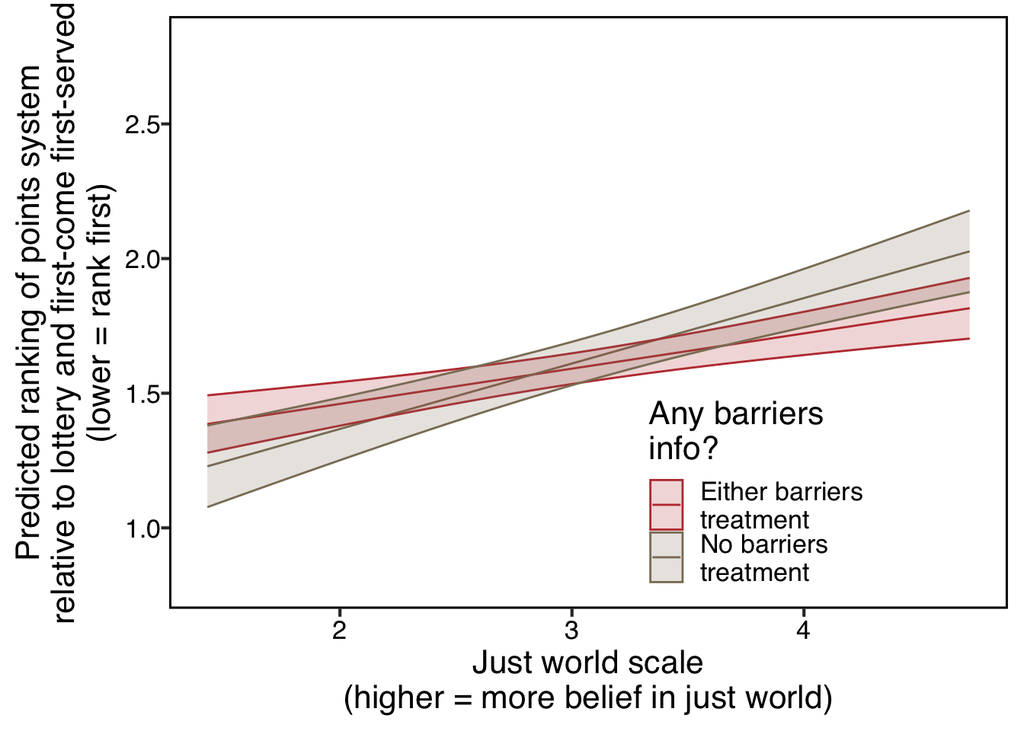

```r
### store ranking obj and do predict- predict ACTUAL RANK
### and not reverse rank to avoid confusion
points_rank_lm_jw = lm(points_rank ~ is_any_barriers*jw_combined,
                       data = model_df)

### doing from top 5% to top 95% of jw scale
###
predict_jw_df = data.frame(is_any_barriers = rep(c(TRUE, FALSE),
                                                 each = 100),
                           jw_combined = rep(seq(from = quantile(model_df$jw_combined,
                                                              probs = 0.05),
                                                 to = quantile(model_df$jw_combined,
                                                              probs = 0.95),
                                                 length.out = 100),
                                             2))

## predict across all values of jw
predicted_rank = predict(points_rank_lm_jw,
                         newdata = predict_jw_df,
                         se.fit = TRUE)

predicted_rank_4graph = cbind(predict_jw_df,
                        data.frame(estimate = predicted_rank$fit,
                        se = predicted_rank$se.fit)) %>%
                mutate(lower = estimate -1.96 *se,
                       upper = estimate + 1.96*se,
                       barriers_4graph = case_when(is_any_barriers ~ "Either barriers\ntreatment",
                                           TRUE ~ "No barriers\ntreatment"))

jw_prediction_graph = ggplot(predicted_rank_4graph, aes(x = jw_combined, y = estimate,
                                  group = barriers_4graph,
                                  color = barriers_4graph)) +
  geom_line() +
  geom_ribbon(aes(ymin = lower, ymax = upper, fill = barriers_4graph),
              alpha = 0.2) +
  theme_new() +
  scale_color_manual(values = col_map_coarse) +
  scale_fill_manual(values = col_map_coarse) +
  theme(legend.position = c(0.7, 0.2),
        legend.background = element_blank()) +
  xlab("Just world scale\n(higher = more belief in just world)") +
  ylab("Predicted ranking of points system\nrelative to lottery and first-come first-served\n(lower = rank first)") +
  ylim(0.8, 2.8) +
  labs(fill = "Any barriers\ninfo?",
       color = "Any barriers\ninfo?")

jw_prediction_graph
```

```r
ggsave(here("output/figs/jw_prediction.png"),
       plot = jw_prediction_graph,
       width = 12,
       height = 8)
```

### 5.5.2 Political affiliation

```r
summary(lm(points_rank ~ is_any_barriers*relevel(factor(political_affil_buckets),
                                                     ref = "Democrat"),
           data = model_df))
```

```
##
## Call:
## lm(formula = points_rank ~ is_any_barriers * relevel(factor(political_affil_buckets),
##     ref = "Democrat"), data = model_df)
##
## Residuals:
##     Min      1Q  Median      3Q     Max
## -1.0676 -0.4294 -0.4294  0.5706  1.6667
##
## Coefficients:
##                                                                                             Estimate
## (Intercept)                                                                                1.429e+00
## is_any_barriersTRUE                                                                        1.628e-05
## relevel(factor(political_affil_buckets), ref = "Democrat")Independent                      3.239e-01
## relevel(factor(political_affil_buckets), ref = "Democrat")Other                           -9.605e-02
## relevel(factor(political_affil_buckets), ref = "Democrat")Republican                       6.382e-01
## is_any_barriersTRUE:relevel(factor(political_affil_buckets), ref = "Democrat")Independent -1.030e-01
## is_any_barriersTRUE:relevel(factor(political_affil_buckets), ref = "Democrat")Other        2.198e-01
## is_any_barriersTRUE:relevel(factor(political_affil_buckets), ref = "Democrat")Republican  -1.310e-01
##                                                                                           Std. Error
## (Intercept)                                                                                5.719e-02
## is_any_barriersTRUE                                                                        7.028e-02
## relevel(factor(political_affil_buckets), ref = "Democrat")Independent                      1.039e-01
## relevel(factor(political_affil_buckets), ref = "Democrat")Other                            1.655e-01
## relevel(factor(political_affil_buckets), ref = "Democrat")Republican                       1.053e-01
## is_any_barriersTRUE:relevel(factor(political_affil_buckets), ref = "Democrat")Independent  1.265e-01
## is_any_barriersTRUE:relevel(factor(political_affil_buckets), ref = "Democrat")Other        2.034e-01
## is_any_barriersTRUE:relevel(factor(political_affil_buckets), ref = "Democrat")Republican   1.298e-01
##                                                                                           t value
## (Intercept)                                                                                24.993
## is_any_barriersTRUE                                                                         0.000
## relevel(factor(political_affil_buckets), ref = "Democrat")Independent                       3.118
## relevel(factor(political_affil_buckets), ref = "Democrat")Other                            -0.580
## relevel(factor(political_affil_buckets), ref = "Democrat")Republican                        6.059
## is_any_barriersTRUE:relevel(factor(political_affil_buckets), ref = "Democrat")Independent  -0.814
## is_any_barriersTRUE:relevel(factor(political_affil_buckets), ref = "Democrat")Other         1.081
## is_any_barriersTRUE:relevel(factor(political_affil_buckets), ref = "Democrat")Republican   -1.009
##                                                                                           Pr(>|t|)
## (Intercept)                                                                                < 2e-16
## is_any_barriersTRUE                                                                        0.99982
## relevel(factor(political_affil_buckets), ref = "Democrat")Independent                      0.00187
## relevel(factor(political_affil_buckets), ref = "Democrat")Other                            0.56183
## relevel(factor(political_affil_buckets), ref = "Democrat")Republican                      1.91e-09
## is_any_barriersTRUE:relevel(factor(political_affil_buckets), ref = "Democrat")Independent  0.41600
## is_any_barriersTRUE:relevel(factor(political_affil_buckets), ref = "Democrat")Other        0.28006
## is_any_barriersTRUE:relevel(factor(political_affil_buckets), ref = "Democrat")Republican   0.31310
##
## (Intercept)                                                                               ***
## is_any_barriersTRUE
## relevel(factor(political_affil_buckets), ref = "Democrat")Independent                     **
## relevel(factor(political_affil_buckets), ref = "Democrat")Other
## relevel(factor(political_affil_buckets), ref = "Democrat")Republican                      ***
## is_any_barriersTRUE:relevel(factor(political_affil_buckets), ref = "Democrat")Independent
## is_any_barriersTRUE:relevel(factor(political_affil_buckets), ref = "Democrat")Other
## is_any_barriersTRUE:relevel(factor(political_affil_buckets), ref = "Democrat")Republican
## ---
## Signif. codes:  0 '***' 0.001 '**' 0.01 '*' 0.05 '.' 0.1 ' ' 1
##
## Residual standard error: 0.7609 on 1043 degrees of freedom
## Multiple R-squared:  0.07864,    Adjusted R-squared:  0.07245
## F-statistic: 12.72 on 7 and 1043 DF,  p-value: 9.768e-16
```

```r
## binary regressing points as first
summary(lm(is_points_first ~ is_any_barriers*relevel(factor(political_affil_buckets),
                                                     ref = "Democrat"),
           data = model_df))
```

```
##
## Call:
## lm(formula = is_points_first ~ is_any_barriers * relevel(factor(political_affil_buckets),
##     ref = "Democrat"), data = model_df)
##
## Residuals:
##     Min      1Q  Median      3Q     Max
## -0.7500 -0.5195  0.3107  0.3170  0.6486
##
## Coefficients:
##                                                                                            Estimate
## (Intercept)                                                                                0.689266
## is_any_barriersTRUE                                                                       -0.006268
## relevel(factor(political_affil_buckets), ref = "Democrat")Independent                     -0.169785
## relevel(factor(political_affil_buckets), ref = "Democrat")Other                            0.060734
## relevel(factor(political_affil_buckets), ref = "Democrat")Republican                      -0.337914
## is_any_barriersTRUE:relevel(factor(political_affil_buckets), ref = "Democrat")Independent  0.032800
## is_any_barriersTRUE:relevel(factor(political_affil_buckets), ref = "Democrat")Other       -0.084157
## is_any_barriersTRUE:relevel(factor(political_affil_buckets), ref = "Democrat")Republican   0.042241
##                                                                                           Std. Error
## (Intercept)                                                                                 0.035927
## is_any_barriersTRUE                                                                         0.044149
## relevel(factor(political_affil_buckets), ref = "Democrat")Independent                       0.065251
## relevel(factor(political_affil_buckets), ref = "Democrat")Other                             0.103970
## relevel(factor(political_affil_buckets), ref = "Democrat")Republican                        0.066166
## is_any_barriersTRUE:relevel(factor(political_affil_buckets), ref = "Democrat")Independent   0.079484
## is_any_barriersTRUE:relevel(factor(political_affil_buckets), ref = "Democrat")Other         0.127785
## is_any_barriersTRUE:relevel(factor(political_affil_buckets), ref = "Democrat")Republican    0.081518
##                                                                                           t value
## (Intercept)                                                                                19.185
## is_any_barriersTRUE                                                                        -0.142
## relevel(factor(political_affil_buckets), ref = "Democrat")Independent                      -2.602
## relevel(factor(political_affil_buckets), ref = "Democrat")Other                             0.584
## relevel(factor(political_affil_buckets), ref = "Democrat")Republican                       -5.107
## is_any_barriersTRUE:relevel(factor(political_affil_buckets), ref = "Democrat")Independent   0.413
## is_any_barriersTRUE:relevel(factor(political_affil_buckets), ref = "Democrat")Other        -0.659
## is_any_barriersTRUE:relevel(factor(political_affil_buckets), ref = "Democrat")Republican    0.518
##                                                                                           Pr(>|t|)
## (Intercept)                                                                                < 2e-16
## is_any_barriersTRUE                                                                         0.8871
## relevel(factor(political_affil_buckets), ref = "Democrat")Independent                       0.0094
## relevel(factor(political_affil_buckets), ref = "Democrat")Other                             0.5592
## relevel(factor(political_affil_buckets), ref = "Democrat")Republican                      3.89e-07
## is_any_barriersTRUE:relevel(factor(political_affil_buckets), ref = "Democrat")Independent   0.6799
## is_any_barriersTRUE:relevel(factor(political_affil_buckets), ref = "Democrat")Other         0.5103
## is_any_barriersTRUE:relevel(factor(political_affil_buckets), ref = "Democrat")Republican    0.6044
##
## (Intercept)                                                                               ***
## is_any_barriersTRUE
## relevel(factor(political_affil_buckets), ref = "Democrat")Independent                     **
## relevel(factor(political_affil_buckets), ref = "Democrat")Other
## relevel(factor(political_affil_buckets), ref = "Democrat")Republican                      ***
## is_any_barriersTRUE:relevel(factor(political_affil_buckets), ref = "Democrat")Independent
## is_any_barriersTRUE:relevel(factor(political_affil_buckets), ref = "Democrat")Other
## is_any_barriersTRUE:relevel(factor(political_affil_buckets), ref = "Democrat")Republican
## ---
## Signif. codes:  0 '***' 0.001 '**' 0.01 '*' 0.05 '.' 0.1 ' ' 1
##
## Residual standard error: 0.478 on 1043 degrees of freedom
## Multiple R-squared:  0.06413,    Adjusted R-squared:  0.05785
## F-statistic: 10.21 on 7 and 1043 DF,  p-value: 2.05e-12
```

### 5.5.3 What’s relationship between political affiliation, just world scale, and pol ideology?

Republicans more evenly distributed throughout ranking distribution and have higher mean just world scale

Independents between dems and r on ideology scale

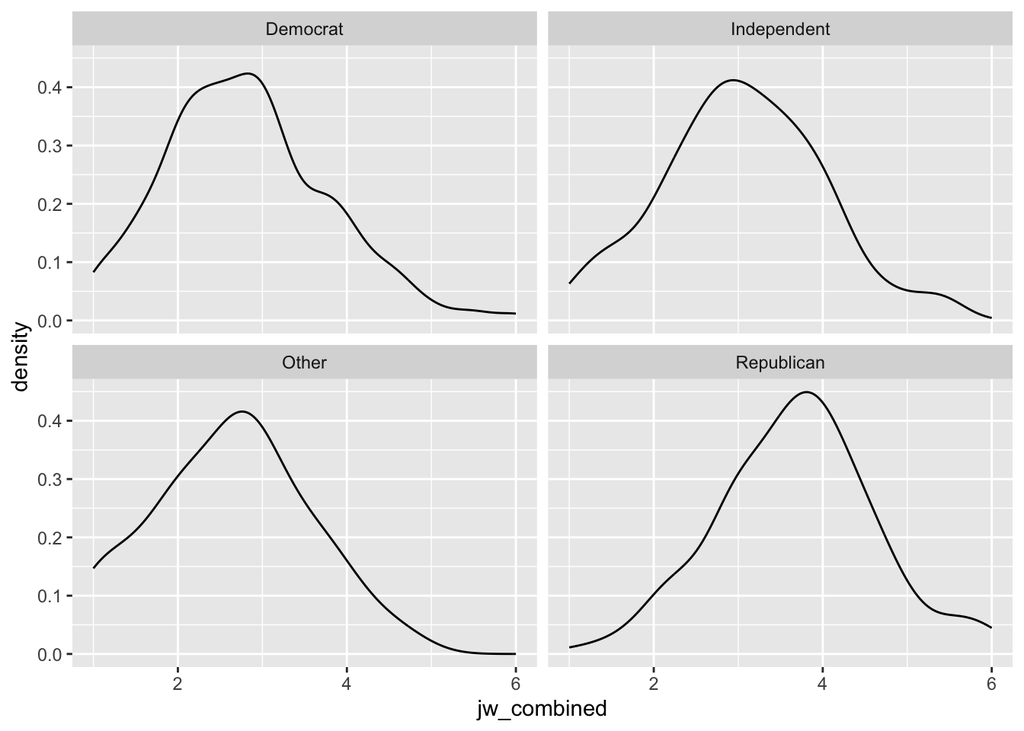

```r
ggplot(model_df, aes(x = jw_combined)) +
  geom_density() +
  facet_wrap(~political_affil_buckets)
```

```r
model_df %>%
  group_by(political_affil_buckets) %>%
  summarise(mean_jw = mean(jw_combined),
            mean_ideology_higher_conserv = mean(political_ideology_numeric,
                                                na.rm = TRUE)) # remove na since coded prefer not/etc to na for numeric version
```

```
## # A tibble: 4 × 3
##   political_affil_buckets mean_jw mean_ideology_higher_conserv
##   <chr>                     <dbl>                        <dbl>
## 1 Democrat                   2.81                         1.94
## 2 Independent                3.05                         2.81
## 3 Other                      2.62                         2.55
## 4 Republican                 3.68                         4.05
```

### 5.5.4 Political ideology

```r
summary(lm(points_rank ~ is_any_barriers*political_ideology_numeric,
           data = model_df))
```

```
##
## Call:
## lm(formula = points_rank ~ is_any_barriers * political_ideology_numeric,
##     data = model_df)
##
## Residuals:
##     Min      1Q  Median      3Q     Max
## -1.1645 -0.4869 -0.2611  0.5403  1.7616
##
## Coefficients:
##                                                 Estimate Std. Error t value
## (Intercept)                                     1.035201   0.101513  10.198
## is_any_barriersTRUE                            -0.018159   0.124167  -0.146
## political_ideology_numeric                      0.225851   0.035604   6.343
## is_any_barriersTRUE:political_ideology_numeric -0.004509   0.043526  -0.104
##                                                Pr(>|t|)
## (Intercept)                                     < 2e-16 ***
## is_any_barriersTRUE                               0.884
## political_ideology_numeric                     3.36e-10 ***
## is_any_barriersTRUE:political_ideology_numeric    0.918
## ---
## Signif. codes:  0 '***' 0.001 '**' 0.01 '*' 0.05 '.' 0.1 ' ' 1
##
## Residual standard error: 0.7504 on 1030 degrees of freedom
##   (17 observations deleted due to missingness)
## Multiple R-squared:  0.1034, Adjusted R-squared:  0.1008
## F-statistic: 39.59 on 3 and 1030 DF,  p-value: < 2.2e-16
```

```r
## binary regressing points as first
summary(lm(is_points_first ~ is_any_barriers*political_ideology_numeric,
           data = model_df))
```

```
##
## Call:
## lm(formula = is_points_first ~ is_any_barriers * political_ideology_numeric,
##     data = model_df)
##
## Residuals:
##     Min      1Q  Median      3Q     Max
## -0.7917 -0.5380  0.2097  0.3358  0.7143
##
## Coefficients:
##                                                  Estimate Std. Error t value
## (Intercept)                                     0.9164591  0.0638253  14.359
## is_any_barriersTRUE                             0.0016527  0.0780694   0.021
## political_ideology_numeric                     -0.1261556  0.0223855  -5.636
## is_any_barriersTRUE:political_ideology_numeric -0.0002091  0.0273664  -0.008
##                                                Pr(>|t|)
## (Intercept)                                     < 2e-16 ***
## is_any_barriersTRUE                               0.983
## political_ideology_numeric                     2.25e-08 ***
## is_any_barriersTRUE:political_ideology_numeric    0.994
## ---
## Signif. codes:  0 '***' 0.001 '**' 0.01 '*' 0.05 '.' 0.1 ' ' 1
##
## Residual standard error: 0.4718 on 1030 degrees of freedom
##   (17 observations deleted due to missingness)
## Multiple R-squared:  0.08542,    Adjusted R-squared:  0.08275
## F-statistic: 32.07 on 3 and 1030 DF,  p-value: < 2.2e-16
```

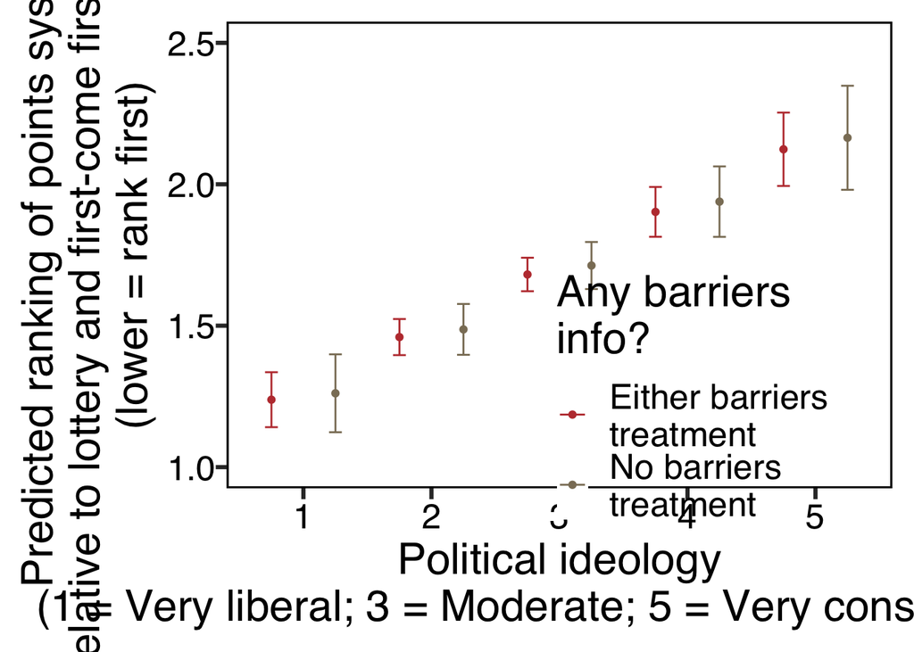

```r
## generate pred using real rank
points_rank_lm_polid = lm(points_rank ~ is_any_barriers*political_ideology_numeric,
                          data = model_df)

predict_polid_df = data.frame(is_any_barriers = rep(c(TRUE, FALSE),
                                                 each = 5),
                           political_ideology_numeric = rep(seq(from = 1,
                                                 to = 5),
                                             2))

## predict across all values of jw
predicted_rank_pol = predict(points_rank_lm_polid,
                         newdata = predict_polid_df,
                         se.fit = TRUE)

predicted_rank_4graph_pol = cbind(predict_polid_df,
                        data.frame(estimate = predicted_rank_pol$fit,
                        se = predicted_rank_pol$se.fit)) %>%
                mutate(lower = estimate -1.96 *se,
                       upper = estimate + 1.96*se,
                       barriers_4graph = case_when(is_any_barriers ~ "Either barriers\ntreatment",
                                           TRUE ~ "No barriers\ntreatment"))

pol_prediction_graph = ggplot(predicted_rank_4graph_pol, aes(x = factor(political_ideology_numeric), y = estimate,
                                  group = barriers_4graph,
                                  color = barriers_4graph)) +
  geom_point(position = position_dodge(width = 1)) +
  geom_errorbar(aes(ymin = lower, ymax = upper, color = barriers_4graph),
              width = 0.2,
              position = position_dodge(width = 1)) +
  theme_new(base_size = 24) +
  scale_color_manual(values = col_map_coarse) +
  theme(legend.position = c(0.7, 0.2),
        legend.background = element_blank()) +
  xlab("Political ideology\n(1 = Very liberal; 3 = Moderate; 5 = Very conservative)") +
  ylab("Predicted ranking of points system\nrelative to lottery and first-come first-served\n(lower = rank first)") +
  ylim(1, 2.5) +
  labs(color = "Any barriers\ninfo?")

pol_prediction_graph
```

```r
ggsave(here("output/figs/pol_prediction.png"),
       plot = pol_prediction_graph,
       width = 12,
       height = 8)


## could relabel with actual values
```

## 5.6 Merge free responses

### 5.6.1 Table summarizing coding

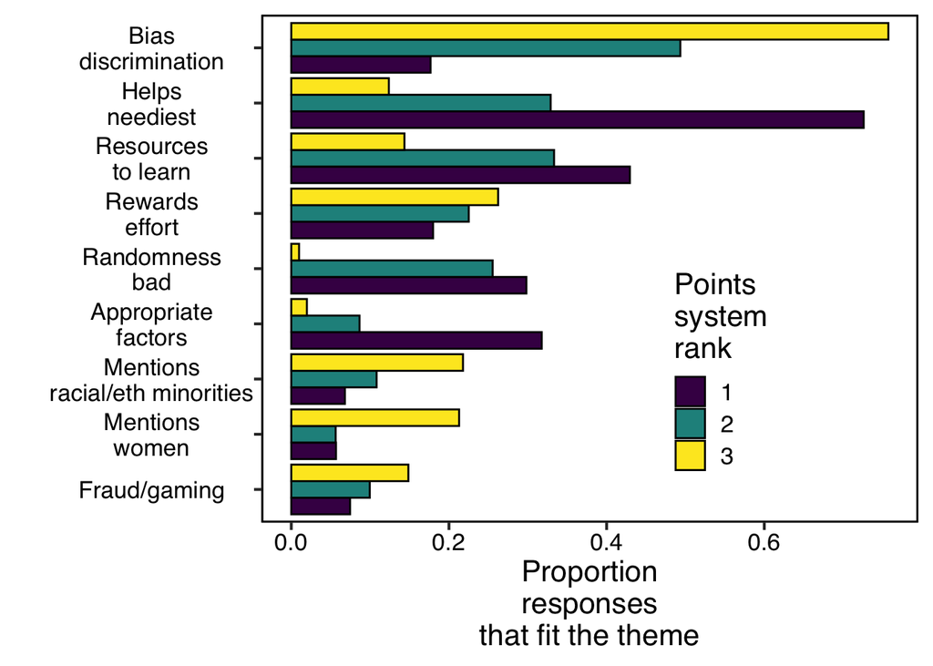

```r
## first, left join fr onto: (1) analytic sample (so not looking at proportions for those excluded
## and (2) limited to treatment and demographics
## joining by prol_id rather than prol_id_clean since
## we didn't do id cleaning before writing for coding
colnames(fr_coded_both) = gsub("\\.+", "_", colnames(fr_coded_both))


fr_thematic_cols = setdiff(colnames(fr_coded_both),
                           c("prol_id", "choice",
                             "fr_why_first_over_second",
                             "fr_why_second_over_third",
                             "coder",
                             "Nonsensical_1_yes_0_no_",
                             "Other_reasons",
                             "Comments_on_other_reasons"))

model_df_wresp= model_df %>%
            select(prol_id, prol_id_clean,
                   cond, points_rank,
                   is_woman, raceeth,
                   is_minority,
                   political_affil,
                   political_affil_buckets,
                   political_ideology,
                   jw_combined) %>%
            left_join(fr_coded_both, by = "prol_id") %>%
            mutate(is_matched_tofr = ifelse(prol_id %in% fr_coded_both$prol_id,
                                            TRUE, FALSE)) %>%
            filter(is_matched_tofr) # one not matched due to not filling out fr but having non-missing DV


## there are 9ish that have NA due to being initially coded as nonsensical
## but that heather reversed codes for--- judgment was that they didnt fit theme so code
## their thematic cols to 0
model_df_wresp[, fr_thematic_cols][is.na(model_df_wresp[, fr_thematic_cols])] <- 0

## find overall proportions
prop_themes_all = data.frame(proportion_resp = colMeans(model_df_wresp[, fr_thematic_cols])) %>%
            arrange(desc(proportion_resp))
prop_themes_all$theme = rownames(prop_themes_all)
write.table(prop_themes_all,
    file = here("output/tables/overall_fr_themes.txt"),
    sep = ",", quote = FALSE, row.names = F)
write.csv(prop_themes_all,
    file = here("output/tables/overall_fr_themes.csv"),
     quote = FALSE, row.names = F)

## proportions by condition
prop_by_cond = model_df_wresp %>%
            group_by(cond) %>%
            summarise_at(.vars = fr_thematic_cols, mean) # for this, among no_info, since half randomzied to points system
            # about women or minorities, those mention that
write.table(prop_by_cond,
    file = here("output/tables/themes_by_treatcondition.txt"),
    sep = ",", quote = FALSE, row.names = F)
write.csv(prop_by_cond,
    file = here("output/tables/themes_by_treatcondition.csv"),
     quote = FALSE, row.names = F)

## proportions by rank for points system
prop_by_rank = model_df_wresp %>%
            group_by(points_rank) %>%
            summarise_at(.vars = fr_thematic_cols, mean) # for this, among no_info, since half randomzied to points system
            # about women or minorities, those mention that
write.table(prop_by_rank,
    file = here("output/tables/themes_by_pointsranking.txt"),
    sep = ",", quote = FALSE, row.names = F)
write.csv(prop_by_rank,
    file = here("output/tables/themes_by_pointsranking.csv"),
     quote = FALSE, row.names = F)



## visualize using shorthand
prop_by_rank_long = reshape2::melt(prop_by_rank, id.var = "points_rank") %>%
              mutate(theme_short =
                    case_when(grepl("^Propensity", variable) ~ "Fraud/gaming",
                              grepl("^Ability", variable) ~ "Helps\nneediest",
                              grepl("personal_resources", variable) ~ "Resources\nto learn",
                              grepl("bias_discrimination", variable) ~ "Bias\ndiscrimination",
                              grepl("reward_applicant", variable) ~ "Rewards\neffort",
                              grepl("randomness", variable) ~ "Randomness\nbad",
                              grepl("appropriate", variable) ~ "Appropriate\nfactors",
                              grepl("^Women", variable) ~ "Mentions\nwomen",
                              grepl("^Racial", variable) ~ "Mentions\nracial/eth minorities"))


ggplot(prop_by_rank_long, aes(x = reorder(factor(theme_short), value), y = value,
                              group = factor(points_rank),
                              fill = factor(points_rank))) +
  geom_bar(stat = "identity", position = "dodge",
           color = "black") +
  coord_flip() +
  theme_new() +
  scale_fill_viridis(discrete = TRUE) +
  ylab("Proportion\nresponses\nthat fit the theme") +
  xlab("") +
  theme(legend.position = c(0.7, 0.3)) +
  labs(fill = "Points\nsystem\nrank")
```

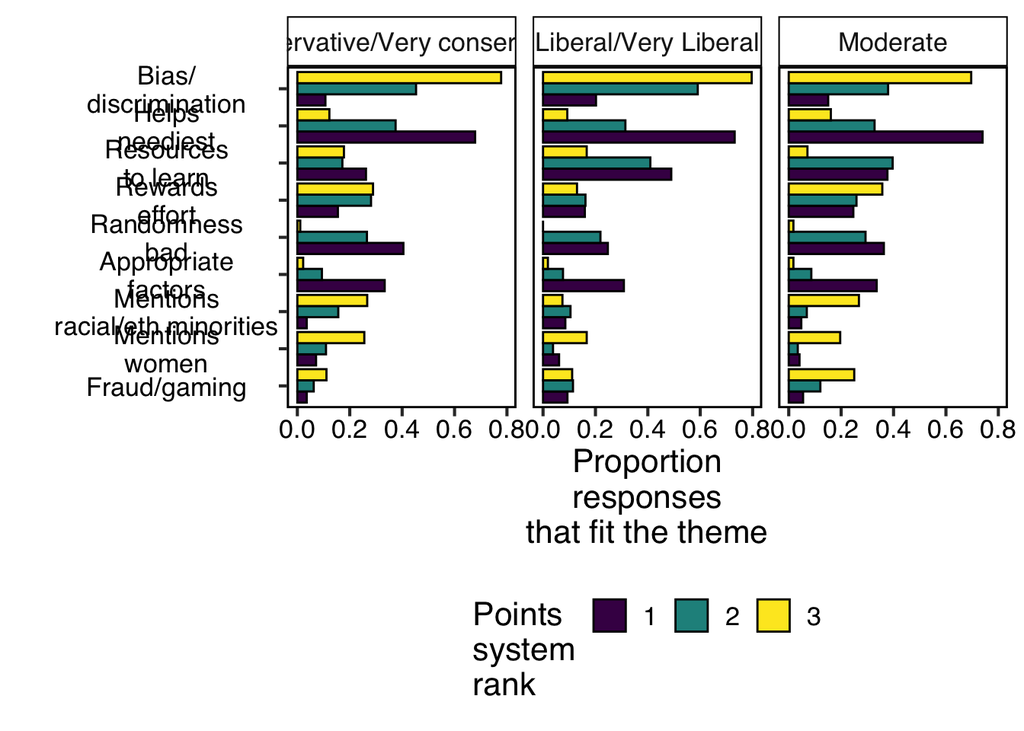

```r
ggsave(here("output/figs/prop_frthemes_byrank.png"),
       plot = last_plot(),
       width = 12,
       height = 8)

## breakdown by political ideology
prop_by_rank_byideol = reshape2::melt(model_df_wresp %>%
            mutate(ideology_broad = case_when(
              grepl("Conservative", political_ideology) ~
                "Conservative/Very conservative",
              grepl("Liberal", political_ideology) ~ "Liberal/Very Liberal",
              grepl("Moderate", political_ideology) ~ "Moderate",
              TRUE ~ "Other"
            )) %>%
            filter(ideology_broad != "Other") %>%
            group_by(ideology_broad, points_rank) %>%
            summarise_at(.vars = fr_thematic_cols, mean),
            id.vars = c("ideology_broad", "points_rank")) %>%
              mutate(theme_short =
                    case_when(grepl("^Propensity", variable) ~ "Fraud/gaming",
                              grepl("^Ability", variable) ~ "Helps\nneediest",
                              grepl("personal_resources", variable) ~ "Resources\nto learn",
                              grepl("bias_discrimination", variable) ~ "Bias/\ndiscrimination",
                              grepl("reward_applicant", variable) ~ "Rewards\neffort",
                              grepl("randomness", variable) ~ "Randomness\nbad",
                              grepl("appropriate", variable) ~ "Appropriate\nfactors",
                              grepl("^Women", variable) ~ "Mentions\nwomen",
                              grepl("^Racial", variable) ~ "Mentions\nracial/eth minorities"))

ggplot(prop_by_rank_byideol, aes(x = reorder(factor(theme_short), value), y = value,
                              group = factor(points_rank),
                              fill = factor(points_rank))) +
  geom_bar(stat = "identity", position = "dodge",
           color = "black") +
  coord_flip() +
  theme_new() +
  scale_fill_viridis(discrete = TRUE) +
  ylab("Proportion\nresponses\nthat fit the theme") +
  xlab("") +
  theme(legend.position = "bottom") +
  labs(fill = "Points\nsystem\nrank") +
  facet_wrap(~ideology_broad, ncol = 3)
```

```r
ggsave(here("output/figs/prop_frthemes_byrank_byideology.png"),
       plot = last_plot(),
       width = 12,
       height = 8)
```

### 5.6.2 Sheet to upload

```r
write.csv(model_df_wresp %>%
      arrange(desc(points_rank),
              political_affil_buckets),
      here("output/fr_forquotes.csv"),
      row.names = FALSE)
```

## 5.7 Robustness check subsetting based on experimenter demand

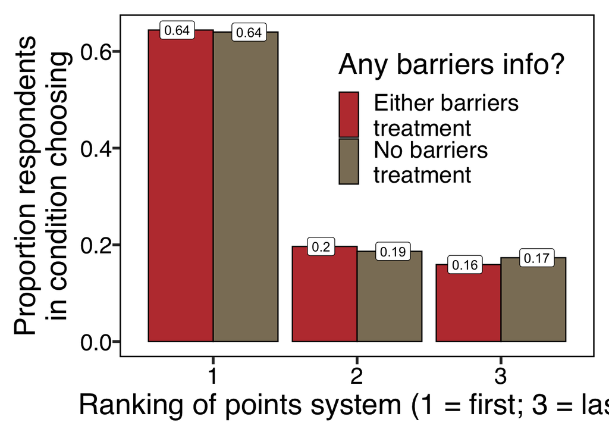

```r
## exclude people who either said:
## (1) want points system most fair or
## (2) might want
model_df_nodemand = model_df %>%
          filter(!grepl("points was the most fair", what_researchers_want)) %>%
          mutate(barriers_4graph = case_when(is_any_barriers ~ "Either barriers\ntreatment",
                                           TRUE ~ "No barriers\ntreatment"),
                 cond_4graph = case_when(cond == "Min" ~ "Barriers\nminorities",
                                       cond == "Wom" ~ "Barriers\nwomen",
                                       cond == "No_info" ~ "No barriers\ntreatment"))

## redo overall proportions
prop_choose_nd = model_df_nodemand %>%
        group_by(points_rank, barriers_4graph) %>%
        summarise(num = n()) %>%
        left_join(model_df_nodemand %>%
                group_by(barriers_4graph) %>%
                summarise(denom = n())) %>%
        mutate(prop_choose = num/denom) %>%
        ungroup()
prop_choose_plot_nd <- ggplot(prop_choose_nd, aes(x = points_rank,
                        y = prop_choose,
                        group = barriers_4graph,
                        fill = barriers_4graph)) +
  geom_bar(stat = "identity",
           position = "dodge", col = "black") +
  theme_new(base_size = 24) +
  scale_fill_manual(values = col_map_coarse) +
  xlab("Ranking of points system (1 = first; 3 = last)") +
  theme(legend.position = c(0.7, 0.7)) +
  labs(fill = "Any barriers info?") +
  geom_label(aes(x = points_rank, y = prop_choose,
                 group = barriers_4graph,

                 label = round(prop_choose, 2)),
             position = position_dodge(width = 1),
             fill = "white") +
  ylab("Proportion respondents\nin condition choosing")

prop_choose_plot_nd
```

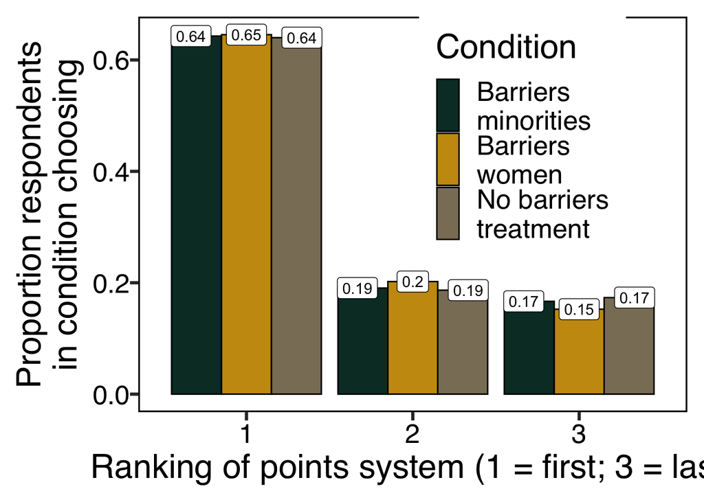

```r
ggsave(here("output/figs/rankings_prop_2groups_excludedemand.png"),
       plot = prop_choose_plot_nd,
       width = 12,
       height = 8)


### repeat for sub ones
prop_choose_detail_nd = model_df_nodemand %>%
        group_by(points_rank, cond_4graph) %>%
        summarise(num = n()) %>%
        left_join(model_df_nodemand %>%
                group_by(cond_4graph) %>%
                summarise(denom = n())) %>%
        mutate(prop_choose = num/denom) %>%
        ungroup()
prop_choose_plot_detail_nd <- ggplot(prop_choose_detail_nd, aes(x = points_rank,
                        y = prop_choose,
                        group = cond_4graph,
                        fill = cond_4graph)) +
  geom_bar(stat = "identity",
           position = "dodge", col = "black") +
  theme_new(base_size = 24) +
  scale_fill_manual(values = col_map_detailed) +
  xlab("Ranking of points system (1 = first; 3 = last)") +
  theme(legend.position = c(0.7, 0.7)) +
  labs(fill = "Condition") +
  geom_label(aes(x = points_rank, y = prop_choose,
                 group = cond_4graph,

                 label = round(prop_choose, 2)),
             position = position_dodge(width = 1),
             fill = "white") +
  ylab("Proportion respondents\nin condition choosing")

prop_choose_plot_detail_nd
```

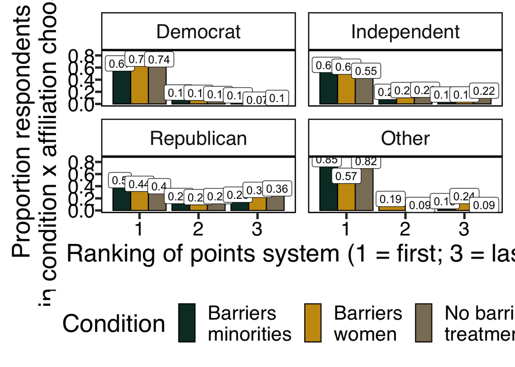

```r
ggsave(here("output/figs/rankings_prop_3groups_nd.png"),
       plot = prop_choose_plot_detail_nd,
       width = 12,
       height = 8)

## do figure on raw rates by political affiliation
prop_choose_detail_waffil_nd = model_df_nodemand %>%
        group_by(points_rank, cond_4graph, political_affil_buckets) %>%
        summarise(num = n()) %>%
        left_join(model_df_nodemand %>%
                group_by(cond_4graph, political_affil_buckets) %>%
                summarise(denom = n())) %>%
        mutate(prop_choose = num/denom) %>%
        ungroup()
prop_choose_plot_detail_waffil_nd <- ggplot(prop_choose_detail_waffil_nd, aes(x = points_rank,
                        y = prop_choose,
                        group = cond_4graph,
                        fill = cond_4graph)) +
  geom_bar(stat = "identity",
           position = "dodge", col = "black") +
  theme_new(base_size = 24) +
  scale_fill_manual(values = col_map_detailed) +
  xlab("Ranking of points system (1 = first; 3 = last)") +
  theme(legend.position = "bottom") +
  labs(fill = "Condition") +
  geom_label(aes(x = points_rank, y = prop_choose,
                 group = cond_4graph,

                 label = round(prop_choose, 2)),
             position = position_dodge(width = 1),
             fill = "white") +
  ylab("Proportion respondents\nin condition x affiliation choosing") +
  facet_wrap(~factor(political_affil_buckets,
                     levels = c("Democrat", "Independent",
                                "Republican", "Other"),
                     ordered = TRUE), ncol = 2)

prop_choose_plot_detail_waffil_nd
```

```r
ggsave(here("output/figs/rankings_prop_3groups_wpoliticalaffil_nd.png"),
       plot = prop_choose_plot_detail_waffil_nd,
       width = 12,
       height = 8)


## run two main regs
## continuous regressing rank of points
## reverse coded so that pos coef = rank higher
m1 <- lm(points_rank ~ is_any_barriers,
           data = model_df_nodemand)

## binary regressing points as first
## use lpm
m2 <- lm(is_points_first ~ is_any_barriers,
           data = model_df_nodemand)

summary(m1)
```

```
##
## Call:
## lm(formula = points_rank ~ is_any_barriers, data = model_df_nodemand)
##
## Residuals:
##     Min      1Q  Median      3Q     Max
## -0.5333 -0.5150 -0.5150  0.4850  1.4850
##
## Coefficients:
##                     Estimate Std. Error t value Pr(>|t|)
## (Intercept)          1.53333    0.04395  34.891   <2e-16 ***
## is_any_barriersTRUE -0.01835    0.05492  -0.334    0.738
## ---
## Signif. codes:  0 '***' 0.001 '**' 0.01 '*' 0.05 '.' 0.1 ' ' 1
##
## Residual standard error: 0.7612 on 832 degrees of freedom
## Multiple R-squared:  0.0001342,  Adjusted R-squared:  -0.001068
## F-statistic: 0.1117 on 1 and 832 DF,  p-value: 0.7383
```

```r
summary(m2)
```

```
##
## Call:
## lm(formula = is_points_first ~ is_any_barriers, data = model_df_nodemand)
##
## Residuals:
##     Min      1Q  Median      3Q     Max
## -0.6442 -0.6400  0.3558  0.3558  0.3600
##
## Coefficients:
##                     Estimate Std. Error t value Pr(>|t|)
## (Intercept)         0.640000   0.027700  23.105   <2e-16 ***
## is_any_barriersTRUE 0.004195   0.034617   0.121    0.904
## ---
## Signif. codes:  0 '***' 0.001 '**' 0.01 '*' 0.05 '.' 0.1 ' ' 1
##
## Residual standard error: 0.4798 on 832 degrees of freedom
## Multiple R-squared:  1.765e-05,  Adjusted R-squared:  -0.001184
## F-statistic: 0.01468 on 1 and 832 DF,  p-value: 0.9036
```

```r
stargazer(m1,
          m2,
           data = model_df_nodemand)
```

```
##
## % Table created by stargazer v.5.2.3 by Marek Hlavac, Social Policy Institute. E-mail: marek.hlavac at gmail.com
## % Date and time: Mon, Jun 02, 2025 - 22:23:26
## \begin{table}[!htbp] \centering
##   \caption{}
##   \label{}
## \begin{tabular}{@{\extracolsep{5pt}}lcc}
## \\[-1.8ex]\hline
## \hline \\[-1.8ex]
##  & \multicolumn{2}{c}{\textit{Dependent variable:}} \\
## \cline{2-3}
## \\[-1.8ex] & points\_rank & is\_points\_first \\
## \\[-1.8ex] & (1) & (2)\\
## \hline \\[-1.8ex]
##  is\_any\_barriers & $-$0.018 & 0.004 \\
##   & (0.055) & (0.035) \\
##   & & \\
##  Constant & 1.533$^{***}$ & 0.640$^{***}$ \\
##   & (0.044) & (0.028) \\
##   & & \\
## \hline \\[-1.8ex]
## Observations & 834 & 834 \\
## R$^{2}$ & 0.0001 & 0.00002 \\
## Adjusted R$^{2}$ & $-$0.001 & $-$0.001 \\
## Residual Std. Error (df = 832) & 0.761 & 0.480 \\
## F Statistic (df = 1; 832) & 0.112 & 0.015 \\
## \hline
## \hline \\[-1.8ex]
## \textit{Note:}  & \multicolumn{2}{r}{$^{*}$p$<$0.1; $^{**}$p$<$0.05; $^{***}$p$<$0.01} \\
## \end{tabular}
## \end{table}
##
## % Table created by stargazer v.5.2.3 by Marek Hlavac, Social Policy Institute. E-mail: marek.hlavac at gmail.com
## % Date and time: Mon, Jun 02, 2025 - 22:23:26
## \begin{table}[!htbp] \centering
##   \caption{}
##   \label{}
## \begin{tabular}{@{\extracolsep{5pt}}lccccc}
## \\[-1.8ex]\hline
## \hline \\[-1.8ex]
```

[output cut: 28 more lines]

```
## fcfs\_rank & 834 & 2.297 & 0.724 & 1 & 3 \\
## is\_missing\_DV & 834 & 0.000 & 0.000 & 0 & 0 \\
## points\_rank\_rev & 834 & 1.478 & 0.761 & 0 & 2 \\
## is\_points\_first & 834 & 0.643 & 0.479 & 0 & 1 \\
## timetrad\_weeks & 834 & 2.305 & 2.115 & 0 & 8 \\
## jw\_combined & 834 & 2.960 & 1.006 & 1.000 & 6.000 \\
## political\_ideology\_numeric & 818 & 2.510 & 1.111 & 1 & 5 \\
## is\_woman & 834 & 0.549 & 0.498 & 0 & 1 \\
## is\_minority & 834 & 0.301 & 0.459 & 0 & 1 \\
## is\_minority\_sec & 834 & 0.210 & 0.407 & 0 & 1 \\
## is\_nonsens\_answer & 834 & 0.000 & 0.000 & 0 & 0 \\
## is\_exact\_dup\_fr & 834 & 0.000 & 0.000 & 0 & 0 \\
## \hline \\[-1.8ex]
## \end{tabular}
## \end{table}
```

## 5.8 Additional viz on descriptive correlations between outcomes

[figure not shown]

```r
jw_poli_ideo_plot = ggplot(model_df, aes(x = factor(political_ideology,
                                                     levels = c("Very Conservative","Conservative", "Moderate",
                                                                "Liberal", "Very Liberal", "Not Sure", "Prefer not to say"),
                                                     ordered = TRUE),
                                            y = jw_combined)) +
  geom_boxplot() +
  #theme_new(base_size = 24) needs to fix the size of x label, could add color too
  scale_fill_manual(values = col_map_coarse) +
  xlab("Political ideology") +
  ylab("Combined just world scale") +
  theme_new() +
  scale_y_continuous(limits = c(from = 0, to = 6),
                    breaks = pretty_breaks(n = 6)) +
  coord_flip()

ggsave(here("output/figs/jw_poli_ideo_plot.png"),
       plot = jw_poli_ideo_plot,
       width = 12,
       height = 8)

jw_poli_affil_plot = ggplot(model_df, aes(x = factor(political_affil_buckets,
                                        levels = c("Democrat",
                                                   "Other",
                                                   "Independent",
                                                   "Republican"),
                                        ordered = TRUE),
                                            y = jw_combined)) +
  geom_boxplot() +
  #theme_new(base_size = 24) needs to fix the size of x label, could add color too
  scale_fill_manual(values = col_map_coarse) +
  xlab("Political ideology") +
  ylab("Combined just world scale") +
  theme_new() +
  scale_y_continuous(limits = c(from = 0, to = 6),
                    breaks = pretty_breaks(n = 6)) +
  coord_flip()

ggsave(here("output/figs/jw_poli_affil_plot.png"),
       plot = jw_poli_affil_plot,
       width = 12,
       height = 8)


#histogram of bjw scores faceted by ideology
jw_poli_affil_plot <- ggplot(model_df, aes(x=political_ideology_numeric, na.rm = TRUE)) +
  geom_histogram(color="black", fill="#c99910") +
  theme_new(base_size = 24) +
  facet_wrap(~factor(political_affil_buckets,
                     levels = c("Democrat", "Independent",
                                "Republican", "Other"),
                     ordered = TRUE)) +
  xlab("Combinded just world scale") +
  ylab("Count")
jw_poli_affil_plot
```

```r
ggsave(here("output/figs/jw_poli_affil_plot.png"),
       plot = jw_poli_affil_plot,
       width = 12,
       height = 8)
```

## 5.9 Ranks beyond points

```r
## distribution of ranks for lottery and fcfc
table(model_df$lottery_rank)
```

```
##
##   1   2   3
## 249 414 388
```

```r
table(model_df$fcfs_rank)
```

```
##
##   1   2   3
## 184 406 461
```